# R Notebook

Robustness checks for all birds phyla models

JQ meeting 29 April 2022 * plot raw data to check effects * arcsine square root transofmr + gaussian model as alt to binomial * can report original model in paper but mention potential over dispersion and that certain results are less robust and certain results more robust

# set up

library(MuMIn) library(arm) library(microbiome) library(dplyr) library(stringr) library(kableExtra)

# Proteobacteria

`r`r proteo.Proportion <- c(proteobacteria.df$Abundance/proteobacteria.df$NumberOfReads)

proteobacteria.df <- cbind(proteobacteria.df, proteo.Proportion)

check effects * Age * brood size * distance to edge * age x habitat * age x brood size * age x distance * age x lay date

`r`r ggplot(proteobacteria.df, aes(ageBinned, proteo.Proportion)) + geom_boxplot()

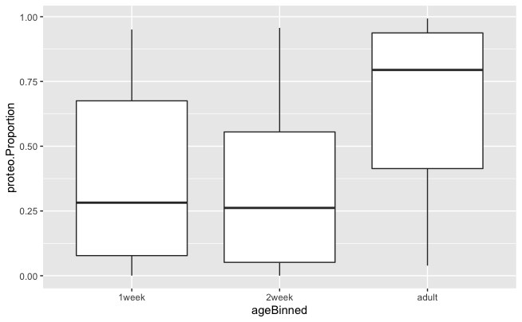

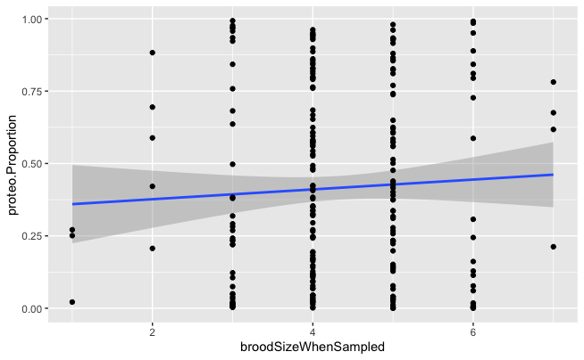

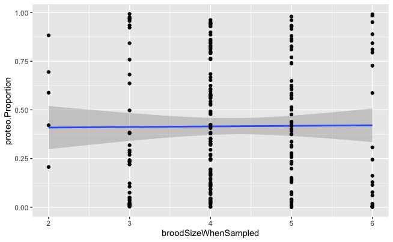

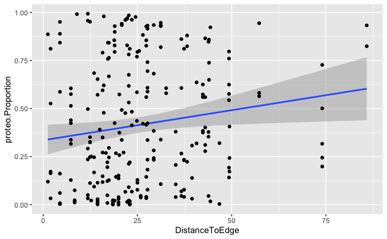

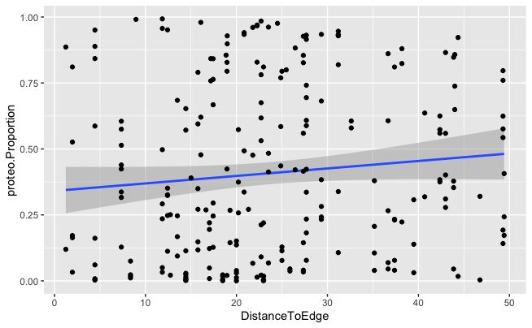

`r`r ggplot(proteobacteria.df, aes(ageBinned, proteo.Proportion, fill = habitat)) + geom_boxplot()

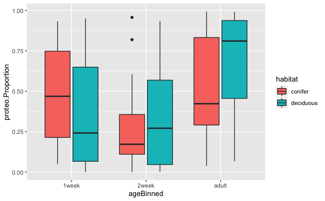

`r`r ggplot(proteobacteria.df, aes(as.factor(broodSizeWhenSampled), proteo.Proportion, fill = ageBinned)) + geom_boxplot()

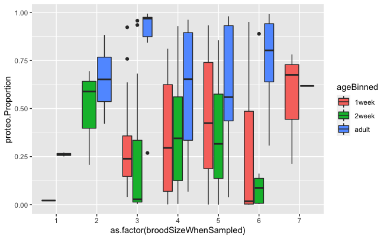

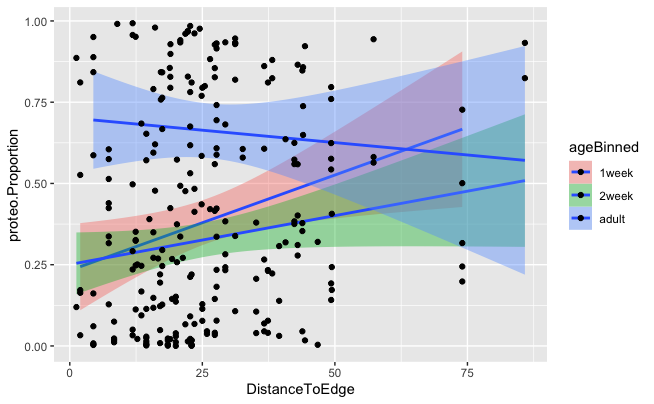

# drop large distance values

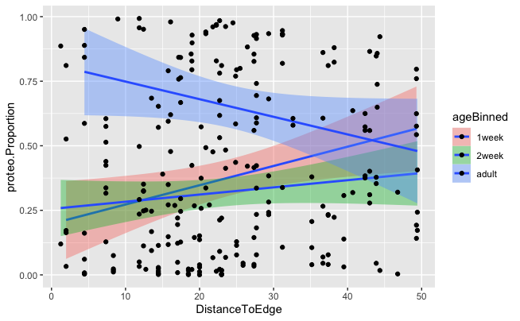

[figure not shown]

```r
ggplot(proteobacteria.df, aes(layDateFirst, proteo.Proportion, fill = ageBinned, label = nest)) +
  geom_smooth(method="lm") +
  geom_point() +
  geom_label()
```

[figure not shown]

```r
# drop large layDateFirst values
ggplot(subset(proteobacteria.df, layDateFirst<80), aes(layDateFirst, proteo.Proportion, fill = ageBinned)) +
#  geom_smooth() +
  geom_smooth(method="lm") +
  geom_point()
```

- Age
- brood size
- distance to edge
- age x habitat
- age x brood size
- age x distance
- age x lay date

# Firmicutes

`r`r firm.Proportion <- c(firmicutes.df$Abundance/firmicutes.df$NumberOfReads)

firmicutes.df <- cbind(firmicutes.df, firm.Proportion)

check effects * Age * brood size * distance to edge * age x habitat * age x brood size * age x distance * age x lay date

`r`r ggplot(firmicutes.df, aes(ageBinned, firm.Proportion)) + geom_boxplot()

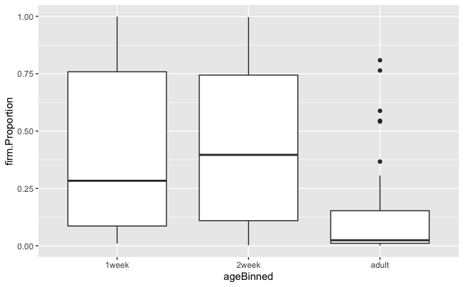

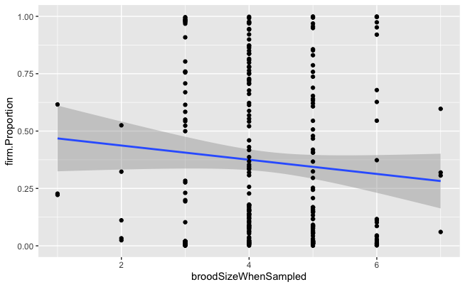

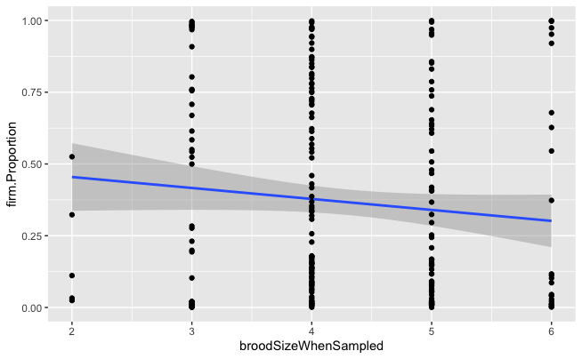

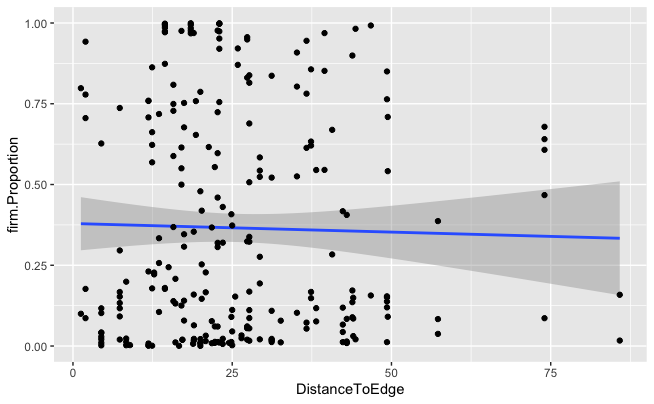

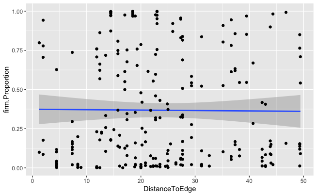

[figure not shown]

[figure not shown]

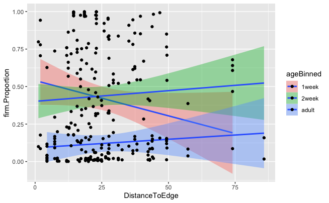

# drop large distance values

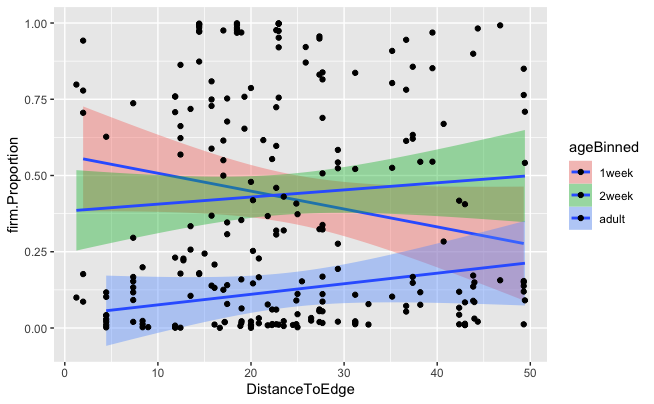

```r
ggplot(firmicutes.df, aes(layDateFirst, firm.Proportion, fill = ageBinned)) +
  geom_smooth(method="lm") +
  geom_point(aes(color = ageBinned))

# drop large layDateFirst values
ggplot(subset(firmicutes.df, layDateFirst<80), aes(layDateFirst, firm.Proportion, fill = ageBinned)) +
#  geom_smooth() +
  geom_smooth(method="lm") +
  geom_point(aes(color = ageBinned))
```

[output not shown]

# Proteobacteria: adults

- lay date
- age
- sex
- brood size
- sex * brood size
- sex * distance
- sex * lay date

```r
proteobacteria.adult.df <- mot[(mot$Phylum=="Proteobacteria" & mot$ageBinned=="adult"),]
firmicutes.adult.df <- mot[(mot$Phylum=="Firmicutes" & mot$ageBinned=="adult"),]
```

```r
proteo.Proportion <- c(proteobacteria.adult.df$Abundance/proteobacteria.adult.df$NumberOfReads)

proteobacteria.adult.df <- cbind(proteobacteria.adult.df, proteo.Proportion)

rm(list = "proteo.Proportion")
```

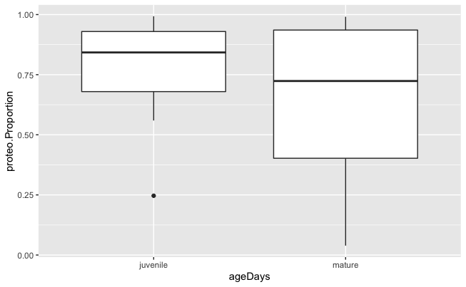

```r
ggplot(proteobacteria.adult.df, aes(ageDays, proteo.Proportion)) +
  geom_boxplot()
```

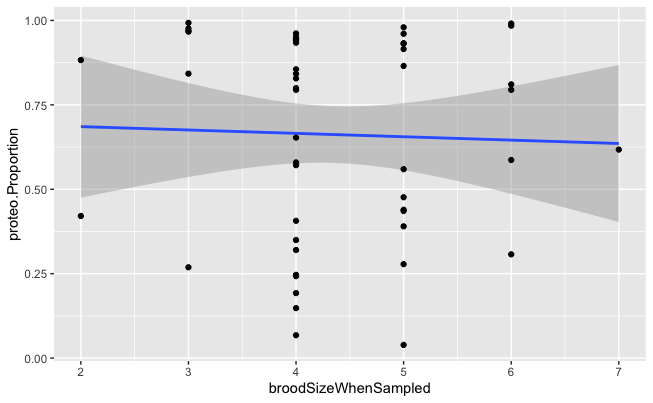

```r
ggplot(proteobacteria.adult.df, aes(broodSizeWhenSampled, proteo.Proportion)) +
 # geom_smooth() +
  geom_smooth(method="lm") +
  geom_point()
```

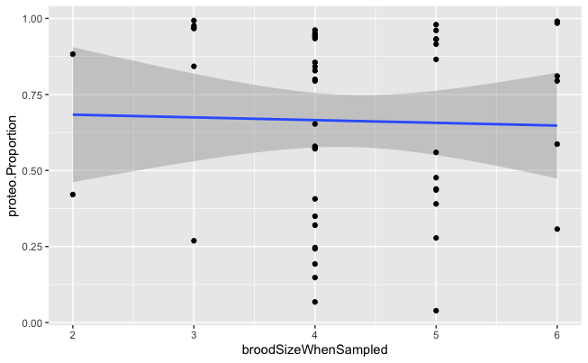

```r
ggplot(subset(proteobacteria.adult.df, broodSizeWhenSampled>1 & broodSizeWhenSampled<7), aes(broodSizeWhenSampled, proteo.Proportion)) +
 # geom_smooth() +
  geom_smooth(method="lm") +
  geom_point()
```

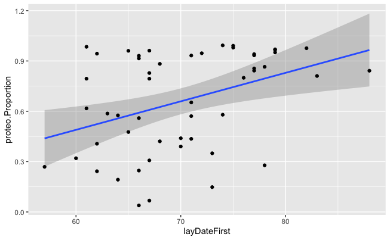

```r
ggplot(proteobacteria.adult.df, aes(layDateFirst, proteo.Proportion)) +
 # geom_smooth() +
  geom_smooth(method="lm") +
  geom_point()
```

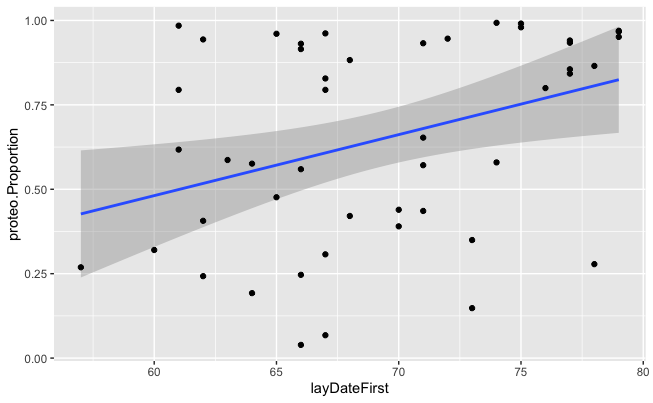

```r
ggplot(subset(proteobacteria.adult.df, layDateFirst<80), aes(layDateFirst, proteo.Proportion)) +
 # geom_smooth() +
  geom_smooth(method="lm") +
  geom_point()
```

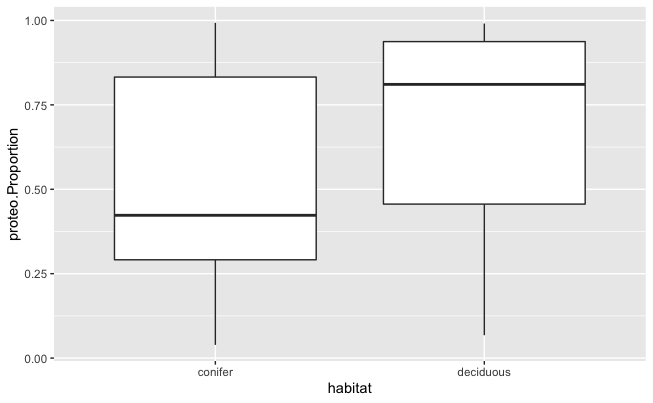

```r
ggplot(proteobacteria.adult.df, aes(habitat, proteo.Proportion)) +
  geom_boxplot()
```

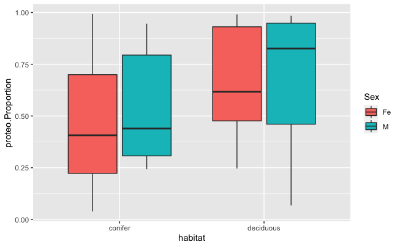

```r
ggplot(proteobacteria.adult.df, aes(habitat, proteo.Proportion, fill = Sex)) +
  geom_boxplot()
```